The datasets we have access to are a population grid estimate from 2003, and a list of health facilities from before the 2010 earthquake, which seems to have primarily been collected in 2005.

Here, roughly, is what a coarse view of (log) population in Haiti looks like:

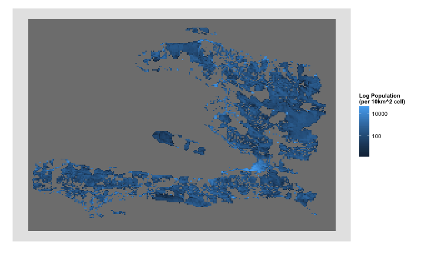

The objective here is to think about population and the health facilities. Lets make a quick plot, to send our minds in the right place; red is health facilities here:

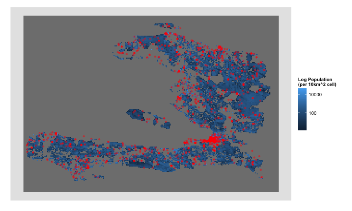

We don't get a very clear picture of things there. Next step is to calculate distances from populated points to facilities.

Finally, lets plot it! Bluer the point, farther away from a health facility. Red points are health facilities, overlaid on top:

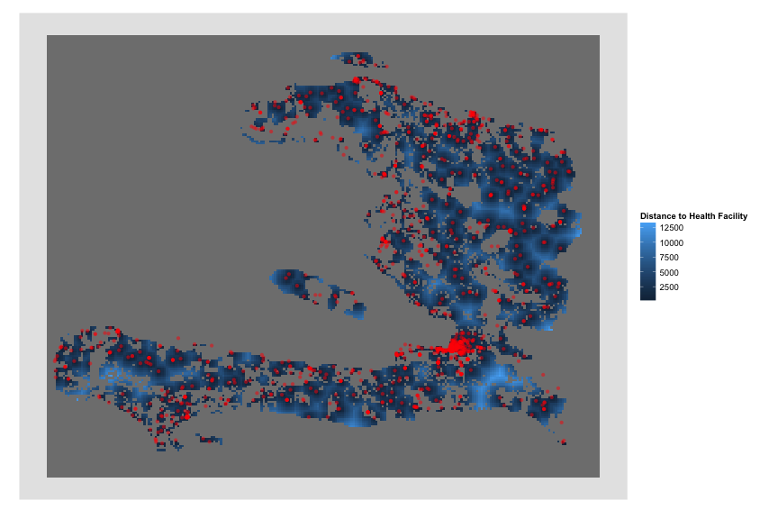

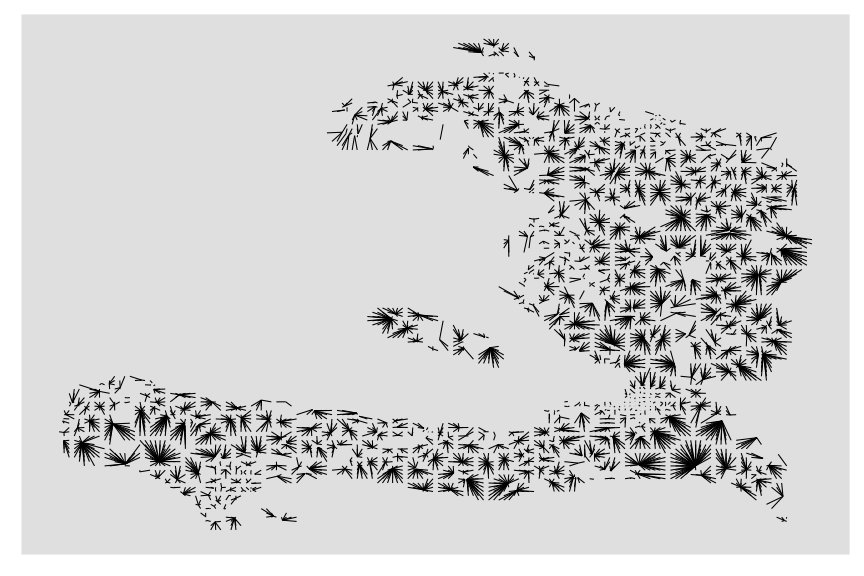

And if we want to look at population as well,

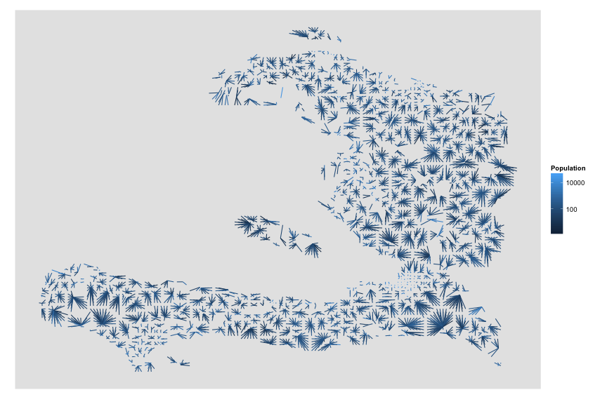

We can also look at the number of people served by a given health facility (roughly), and look at that according to the type of the health facility. For example, small clinics that are serving huge populations may be due for an upgrade. Unfortunately, the typology in our dataset isn't great, but nevertheless, here is a broad brush picture:

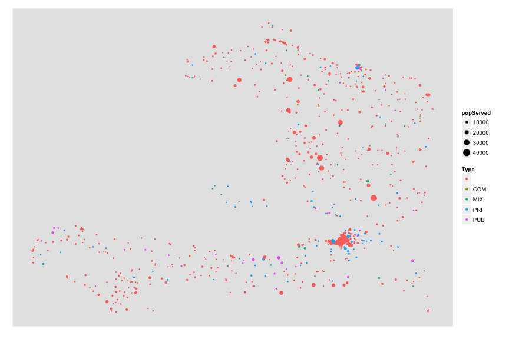